# R Notebook

```r
library(uwIntroStats)
```

```r
library(data.table)
library(ggplot2)
library(gridExtra)
library(grid)
library(stringr)

hers <- as.data.table(read.csv("data/HERSdatasub.csv", header=TRUE))

# Variable Setup
hers[,LDL.diff:=LDL.1-LDL]
hers[,HDL.diff:=HDL.1-HDL]
hers[,BMI.diff:=BMI.1-BMI]
hers[,TG.diff:=TG.1-TG]
hers[,glucose.diff:=glucose.1-glucose]
hers[,TG.HDL.ratio:=TG/HDL]
hers[,TG.HDL.ratio.1:=TG.1/HDL.1]
hers[,TG.HDL.ratio.ratio:=TG.HDL.ratio.1/TG.HDL.ratio]

# Indicator variable for predictor
hers[,treatment:=ifelse(HT=='placebo', 0, 1)]

# Other Indicators
hers[,smoking:=ifelse(smoking=='yes', 1, 0)]
hers[,drinkany:=ifelse(drinkany=='yes', 1, 0)]
hers[,exercise:=ifelse(exercise=='yes', 1, 0)]
hers[,statins:=ifelse(statins=='yes', 1, 0)]
hers[,diabetes:=ifelse(statins=='yes', 1, 0)]

# African American = 0, other = 1, White = 2
hers[,raceth:=as.integer(raceth) - 1]

# Blood pressure categorical var based on http://www.acc.org/latest-in-cardiology/articles/2017/11/08/11/47/mon-5pm-bp-guideline-aha-2017
bp_level_names = c('normal', 'elevated', 'stage1', 'stage2', 'crisis')

bp_cat <- function(sbp, dbp) {
  if(sbp < 120 && dbp < 80) 0
  else if(sbp < 130 && dbp < 80) 1
  else if(sbp < 140 || dbp < 90) 2
  else if((sbp >= 140 && sbp < 180) || (dbp >= 90 && dbp < 120)) 3
  else if(sbp > 180 || dbp > 120) 4
  else NA
}

hers[,bp.category:=bp_cat(SBP, DBP)]
table(hers$bp.category)
```

```
##
##    2
## 2763
```

```r
outcome_vars <- c("LDL.1", "HDL.1", "TG.1", "TG.HDL.ratio.1",  "LDL.diff", "HDL.diff", "TG.diff", "TG.HDL.ratio.ratio")
```

```r
hers
```

| HT | age | raceth | smoking | drinkany | exercise | statins | diabetes | BMI | glucose | BMI.1 | glucose.1 | LDL | HDL | TG | LDL.1 | HDL.1 | TG.1 | SBP | DBP | LDL.diff | HDL.diff | BMI.diff | TG.diff | glucose.diff | TG.HDL.ratio | TG.HDL.ratio.1 | TG.HDL.ratio.ratio | treatment | bp.category |
| --- | --- | --- | --- | --- | --- | --- | --- | --- | --- | --- | --- | --- | --- | --- | --- | --- | --- | --- | --- | --- | --- | --- | --- | --- | --- | --- | --- | --- | --- |
| placebo | 70 | 0 | 0 | 0 | 0 | 1 | 0 | 23.69 | 84 | 23.63 | 94 | 122.4 | 52 | 73 | 137.6 | 48 | 77 | 138 | 78 | 15.2000046 | -4 | -0.060001373 | 4 | 10 | 1.4038462 | 1.6041667 | 1.1426941 | 0 | 2 |
| placebo | 62 | 0 | 0 | 0 | 0 | 0 | 0 | 28.62 | 111 | 28.89 | 78 | 241.6 | 44 | 107 | 150.6 | 48 | 87 | 118 | 70 | -91.0000000 | 4 | 0.269998550 | -20 | -33 | 2.4318182 | 1.8125000 | 0.7453271 | 0 | 2 |
| hormone therapy | 69 | 2 | 0 | 0 | 0 | 0 | 0 | 42.51 | 114 | 40.73 | 98 | 166.2 | 57 | 154 | 156.0 | 66 | 160 | 134 | 78 | -10.1999969 | 9 | -1.779998779 | 6 | -16 | 2.7017544 | 2.4242424 | 0.8972845 | 1 | 2 |
| placebo | 64 | 2 | 1 | 1 | 0 | 0 | 0 | 24.39 | 94 | 22.52 | 93 | 116.2 | 56 | 159 | 122.6 | 57 | 137 | 152 | 72 | 6.4000015 | 1 | -1.869998932 | -22 | -1 | 2.8392857 | 2.4035088 | 0.8465188 | 0 | 2 |
| placebo | 65 | 2 | 0 | 0 | 0 | 0 | 0 | 21.90 | 101 | 22.28 | 92 | 150.6 | 42 | 107 | 172.2 | 35 | 139 | 175 | 95 | 21.5999908 | -7 | 0.380001068 | 32 | -9 | 2.5476190 | 3.9714286 | 1.5588785 | 0 | 2 |
| hormone therapy | 68 | 0 | 0 | 1 | 0 | 0 | 0 | 29.05 | 116 | 27.52 | 115 | 137.8 | 52 | 111 | 126.6 | 53 | 112 | 174 | 98 | -11.2000046 | 1 | -1.529998779 | 1 | -1 | 2.1346154 | 2.1132075 | 0.9899711 | 1 | 2 |
| placebo | 70 | 2 | 0 | 0 | 0 | 0 | 0 | 34.45 | 120 | NA | NA | 228.8 | 33 | 261 | NA | NA | NA | 119 | 61 | NA | NA | NA | NA | NA | 7.9090909 | NA | NA | 0 | 2 |
| hormone therapy | 69 | 2 | 0 | 0 | 1 | 1 | 0 | 23.16 | 95 | 23.99 | 95 | 121.2 | 46 | 139 | 113.4 | 54 | 113 | 178 | 82 | -7.7999954 | 8 | 0.829999924 | -26 | 0 | 3.0217391 | 2.0925926 | 0.6925127 | 1 | 2 |
| hormone therapy | 61 | 2 | 0 | 1 | 1 | 0 | 0 | 30.26 | 105 | 31.45 | 113 | 133.0 | 50 | 150 | 106.2 | 57 | 239 | 162 | 70 | -26.8000031 | 7 | 1.190000534 | 89 | 8 | 3.0000000 | 4.1929825 | 1.3976608 | 1 | 2 |
| hormone therapy | 62 | 2 | 1 | 1 | 0 | 0 | 0 | 45.68 | 98 | 40.64 | 98 | 220.0 | 40 | 215 | 173.2 | 39 | 139 | 111 | 71 | -46.8000031 | -1 | -5.040000916 | -76 | 0 | 5.3750000 | 3.5641026 | 0.6630888 | 1 | 2 |

[output cut: 2753 more lines]

# Question 3

**Is there any attenuation of the hormone therapy treatment effects after adjustment for known risk factors for CHD?**

## Participants:

consisted of 2,763 women who were younger than 80 years, postmenopausal with an intact uterus, and had high risk of CHD events at the time of enrollment.

## Treatment Arms:

1. Hormone therapy
2. Placebo

## Length of Followup

> = 4 Years

## Focus

For this project, we are interested in the effect of hormone therapy on plasma lipid biomarkers for CHD after one year of treatment. In particular, it is of primary interest to assess the effects of hormone therapy on cholesterol levels and triglyceride levels at the end of year 1 in this clinical trial for hormone therapy replacement.

## Thoughts and Notes

We need to define what the treatment effects are. The focus is the change in plasma lipid biomarkers for CHD after 1 year of treatment. We have two treatment arms, so we will look at the difference in these biomarkers from baseline.

The relevant variables are: * SBP and DBP - high systolic and diastolic blood pressure has been found to be a risk factor for heart disease. Apparently using both provides more predictive power: https://www.sciencedaily.com/releases/2009/02/090218181909.htm. However, we don’t have blood pressure measures at year 1

These variables have values at both baseline and year 1: * BMI - Body mass index obviously * glucose - levels of blood glucose * LDL - Low-density lipoprotein cholesterol. High levels are associated with CHD. * HDL - High-density lipoprotein cholesterol. High levels are negatively associated with CHD. * TG - Triglyceride (fat) levels, where higher levels are associated with CHD.

Basically, in question 2, they ask about unadjusted effects. In question 3, they suggest adjusting for these effects.

We can look at the analysis a couple of ways, but what makes most sense is to have the null hypothesis that there is “no mean treatment effect within strata of a baseline set of variables.” To undertake this analysis, we need to determine what our outcome variables are.

*Option 1:* Use the difference between baseline and year 1 for HDL, LDL, TG, glucose, and BMI. This analysis would investigate the effect that the treatment has on the change of an individual’s CHD risk factors, and is more likely to control for some of the inter-individual variability of teh measures. For example, an individual on the high end of the spectrum in these metrics in the treatment branch that had the levels drop significantly but still remain high would have the treatment effect captured; In option 2, this effect would not have been captured. In general, since we have both time points, might make more sense to go with this option, especially since common-sense interpretation of the effect of a drug is that it lowers a given individual’s risk factors. The results seem like they would be more easily interpretable, and use more of the available information.

*Option 2:* Use the raw values for the levels of the variables at year 1; This does not account for the scenario outlined in option 1.

*Option 3:* Test the hypothesis that the slope of the outcome variables is 0 between the two time points, and then stratify by treatment group. This is a bit confusing: the POI is the timepoint (year0 vs year1), the outcome variables are the same, but the analysis can be stratified by treatment.

### Determining Risk Factors and Outcome variables

It’s a bit difficult to figure out from the description of the project what the actual outcome variables are, and what the CDH risk factors are. It seems like the main outcome variables are the plasma lipid biomarkers (LDL, HDL, TG). This leaves glucose, blood pressure, BMI as the main risk factors.

**I know we’re not supposed to use outside sources, but apparently there’s evidence that the important CHD risk factor is TG : HDL.** Since this variable is a ratio, we’d likely want to talk about % increases in this ratio, so using a log-tranformed outcome would make sense.

- https://www.mayoclinic.org/diseases-conditions/high-blood-cholesterol/expert-answers/cholesterol-ratio/faq-20058006
- https://www.ncbi.nlm.nih.gov/pmc/articles/PMC2664115/

### Simplest Approach: un-adjusted uni-variate analysis

outcome: the outcome vars predictor of interest: treatment group

#### Box Plots

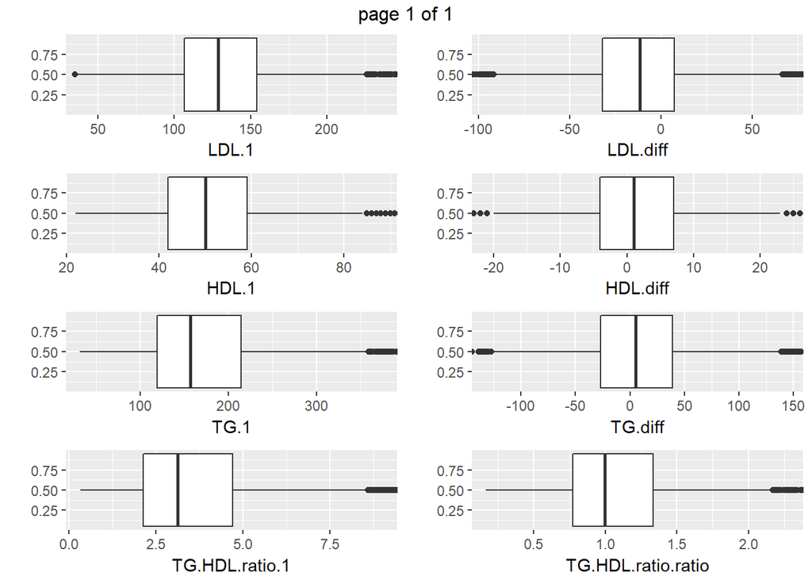

```r
boxplots <- lapply(outcome_vars, function(outcome) {
    ylim = boxplot.stats(hers[[outcome]])$stats[c(1, 5)]
    ggplot(hers, aes_string(x='treatment', y=outcome)) + geom_boxplot() + coord_flip(ylim = ylim*1.05) + xlab("");
  })

m <- marrangeGrob(grobs=boxplots, ncol=2, nrow=4)
m
```

It seems like difference and raw values both follow the same pattern (which makes sense).

### Linear Regression

```r
  names(outcome_vars) <- outcome_vars
  lms <- lapply(outcome_vars, function(outcome) {
    f <- paste(outcome, "~ treatment")
    do.call("regress", list("mean", as.formula(f), data=as.name("hers")))
  })

  temp <- lapply(lms, function(lm){
    print(paste(str_pad(paste(lm$args, collapse=' ~ '), side='left', width=30), paste(round(lm$coefficients[2, ], digit=4), collapse=' '), sep=' | '))
  })
```

```
## [1] "             LDL.1 ~ treatment | -15.2165 1.4993 1.4982 -18.1542 -12.2788 -10.1568 0"
## [1] "             HDL.1 ~ treatment | 4.607 0.5358 0.5363 3.5554 5.6587 8.5899 0"
## [1] "              TG.1 ~ treatment | 11.1146 3.2978 3.3014 4.6411 17.5882 3.3667 8e-04"
## [1] "    TG.HDL.ratio.1 ~ treatment | -0.1606 0.1002 0.1002 -0.3571 0.0359 -1.6028 0.1091"
## [1] "          LDL.diff ~ treatment | -15.5893 1.3283 1.3283 -18.1939 -12.9848 -11.7366 0"
## [1] "          HDL.diff ~ treatment | 5.3514 0.3752 0.3755 4.6151 6.0877 14.2509 0"
## [1] "           TG.diff ~ treatment | 13.2112 2.7134 2.7175 7.8824 18.5399 4.8615 0"
## [1] "TG.HDL.ratio.ratio ~ treatment | -0.0379 0.0222 0.0221 -0.0813 0.0055 -1.7109 0.0872"
```

Again, all are highly significant except the TG/HDL ratio measures. That’s definitely interesting; if this ratio is strongly predictive of CHD, the fact the treatment does not really affect it as much might be troubling.

So, this is a good possibly a good summary of Q2 results. I’ll focus on the difference variables (`LDL.diff`, `HDL.diff`, `TG.diff`).

## Q3 Analysis

Outcome variables: `LDL.diff`, `HDL.diff`, and `TG.diff` Predictor variable: `treatment` “Known” Risk factors: `age`, `race`, `BMI`, `smoking`, `drinkany`, `excercise`, `diabetes` Possible: `statins`

I’m not sure whether to include statins as a risk factor, since they are also a treatment; However, since they might have a huge effect on the response, I’ll include them. Might want to determine if these risk factors are precision/confounder/effect modifiers etc.

```r
hers[diabetes == 1]
```

| HT | age | raceth | smoking | drinkany | exercise | statins | diabetes | BMI | glucose | BMI.1 | glucose.1 | LDL | HDL | TG | LDL.1 | HDL.1 | TG.1 | SBP | DBP | LDL.diff | HDL.diff | BMI.diff | TG.diff | glucose.diff | TG.HDL.ratio | TG.HDL.ratio.1 | TG.HDL.ratio.ratio | treatment | bp.category |
| --- | --- | --- | --- | --- | --- | --- | --- | --- | --- | --- | --- | --- | --- | --- | --- | --- | --- | --- | --- | --- | --- | --- | --- | --- | --- | --- | --- | --- | --- |

### Adjusting for all of the risk factors

```r
  main_outcome_vars <- c('LDL.diff', 'HDL.diff', 'TG.diff')
  risk_factors <- c('age', 'raceth', 'BMI', 'smoking', 'drinkany', 'exercise', 'statins', 'bp.category')
  names(main_outcome_vars) <- main_outcome_vars
  lms.adjusted <- lapply(main_outcome_vars, function(outcome) {
    f <- paste(outcome, "~ treatment +", paste(risk_factors, collapse=' + '))
    do.call("regress", list("mean", as.formula(f), data=as.name("hers")))
  })

  temp <- lapply(lms.adjusted, function(lm){
    print(paste(str_pad(paste(lm$args, collapse=' ~ '), side='left', width=30), paste(round(lm$coefficients[2, ], digit=4), collapse=' '), sep=' | '))
  })
```

```
## [1] "LDL.diff ~ treatment ~ age ~ raceth ~ BMI ~ smoking ~ drinkany ~ exercise ~ statins ~ bp.category | -15.4648 1.3272 1.3274 -18.0677 -12.8619 -11.6502 0"
## [1] "HDL.diff ~ treatment ~ age ~ raceth ~ BMI ~ smoking ~ drinkany ~ exercise ~ statins ~ bp.category | 5.3337 0.3761 0.3785 4.5914 6.0759 14.0906 0"
## [1] "TG.diff ~ treatment ~ age ~ raceth ~ BMI ~ smoking ~ drinkany ~ exercise ~ statins ~ bp.category | 13.1751 2.7205 2.7235 7.8346 18.5156 4.8375 0"
```

#### Compare this to the unadjusted regression analysis:

```r
  names(main_outcome_vars) <- main_outcome_vars
  lms <- lapply(main_outcome_vars, function(outcome) {
    f <- paste(outcome, "~ treatment")
    do.call("regress", list("mean", as.formula(f), data=as.name("hers")))
  })

  temp <- lapply(lms, function(lm){
    print(paste(str_pad(paste(lm$args, collapse=' ~ '), side='left', width=30), paste(round(lm$coefficients[2, ], digit=4), collapse=' '), sep=' | '))
  })
```

```
## [1] "          LDL.diff ~ treatment | -15.5893 1.3283 1.3283 -18.1939 -12.9848 -11.7366 0"
## [1] "          HDL.diff ~ treatment | 5.3514 0.3752 0.3755 4.6151 6.0877 14.2509 0"
## [1] "           TG.diff ~ treatment | 13.2112 2.7134 2.7175 7.8824 18.5399 4.8615 0"
```

#### Full adjusted models:

##### LDL.diff

```r
print(lms.adjusted$LDL.diff)
```

```
## ( 172  cases deleted due to missing values)
##
##
## Call:
## regress(fnctl = "mean", formula = LDL.diff ~ treatment + age +
##     raceth + BMI + smoking + drinkany + exercise + statins +
##     bp.category, data = hers)
##
## Residuals:
##      Min       1Q   Median       3Q      Max
## -209.795  -17.887    0.383   19.238  235.767
##
## Coefficients: (1 not defined because of singularities)
##                   Estimate  Naive SE  Robust SE    95%L      95%H
## [1]  Intercept     -1.483     8.876     9.167       -19.46     16.49
## [2]  treatment     -15.46     1.327     1.327       -18.07    -12.86
## [3]  age          -0.04861    0.1044    0.1041      -0.2526    0.1554
## [4]  raceth        -0.6294    1.257     1.506       -3.583     2.325
## [5]  BMI           -0.1001    0.1271    0.1214      -0.3381    0.1378
## [6]  smoking        1.183     2.084     2.108       -2.950     5.315
## [7]  drinkany       1.929     1.377     1.361       -0.7401    4.597
## [8]  exercise       1.794     1.399     1.398       -0.9468    4.535
## [9]  statins        6.248     1.381     1.417        3.470     9.027
## [10] category       0.0000     NA        NA           NA        NA
##                      F stat    df Pr(>F)
## [1]  Intercept            0.03  1   0.8715
## [2]  treatment          135.73  1 < 0.00005
## [3]  age                  0.22  1   0.6404
## [4]  raceth               0.17  1   0.6761
## [5]  BMI                  0.68  1   0.4093
## [6]  smoking              0.31  1   0.5748
## [7]  drinkany             2.01  1   0.1566
## [8]  exercise             1.65  1   0.1994
## [9]  statins             19.45  1 < 0.00005
## [10] category               NA NA       NA
##
##  Predictor(s) dropped due to overfitting
##
## Residual standard error: 33.75 on 2582 degrees of freedom
##   (172 observations deleted due to missingness)
## Multiple R-squared:  0.05983,    Adjusted R-squared:  0.05692
## F-statistic: 20.18 on 8 and 2582 DF,  p-value: < 2.2e-16
```

##### HDL.diff

```r
lms.adjusted$HDL.diff
```

```
## ( 172  cases deleted due to missing values)
##
##
## Call:
## regress(fnctl = "mean", formula = HDL.diff ~ treatment + age +
##     raceth + BMI + smoking + drinkany + exercise + statins +
##     bp.category, data = hers)
##
## Residuals:
##     Min      1Q  Median      3Q     Max
## -43.660  -5.291  -0.144   5.077  65.937
##
## Coefficients: (1 not defined because of singularities)
##                   Estimate  Naive SE  Robust SE    95%L      95%H
## [1]  Intercept     -0.9113    2.516     2.622       -6.053     4.230
## [2]  treatment      5.334     0.3761    0.3785       4.591     6.076
## [3]  age           0.01281   0.02958   0.03081     -0.04760   0.07322
## [4]  raceth        -0.1936    0.3562    0.4134      -1.004     0.6171
## [5]  BMI          -0.02670   0.03603   0.03474     -0.09483   0.04142
## [6]  smoking       0.04790    0.5907    0.6062      -1.141     1.237
## [7]  drinkany      -0.3378    0.3903    0.3932      -1.109     0.4332
## [8]  exercise       0.4215    0.3965    0.3935      -0.3501    1.193
## [9]  statins       0.05615    0.3913    0.3928      -0.7140    0.8263
## [10] category       0.0000     NA        NA           NA        NA
##                      F stat    df Pr(>F)
## [1]  Intercept            0.12  1   0.7282
## [2]  treatment          198.54  1 < 0.00005
## [3]  age                  0.17  1   0.6776
## [4]  raceth               0.22  1   0.6396
## [5]  BMI                  0.59  1   0.4422
## [6]  smoking              0.01  1   0.9370
## [7]  drinkany             0.74  1   0.3904
## [8]  exercise             1.15  1   0.2842
## [9]  statins              0.02  1   0.8863
## [10] category               NA NA       NA
##
##  Predictor(s) dropped due to overfitting
##
## Residual standard error: 9.564 on 2582 degrees of freedom
##   (172 observations deleted due to missingness)
## Multiple R-squared:  0.07352,    Adjusted R-squared:  0.07064
## F-statistic: 26.51 on 8 and 2582 DF,  p-value: < 2.2e-16
```

##### TG.diff

```r
lms.adjusted$TG.diff
```

```
## ( 160  cases deleted due to missing values)
##
##
## Call:
## regress(fnctl = "mean", formula = TG.diff ~ treatment + age +
##     raceth + BMI + smoking + drinkany + exercise + statins +
##     bp.category, data = hers)
##
## Residuals:
##     Min      1Q  Median      3Q     Max
## -227.81  -37.36   -4.58   28.36  783.09
##
## Coefficients: (1 not defined because of singularities)
##                   Estimate  Naive SE  Robust SE    95%L      95%H
## [1]  Intercept      23.04     18.19     17.85       -11.96     58.04
## [2]  treatment      13.18     2.720     2.724        7.835     18.52
## [3]  age           -0.3445    0.2138    0.2100      -0.7563   0.06740
## [4]  raceth         4.215     2.570     2.277       -0.2493    8.679
## [5]  BMI           -0.1319    0.2606    0.2353      -0.5932    0.3295
## [6]  smoking       -6.435     4.246     4.387       -15.04     2.167
## [7]  drinkany      -3.122     2.824     2.746       -8.506     2.262
## [8]  exercise       1.233     2.870     2.841       -4.339     6.804
## [9]  statins        3.091     2.832     2.847       -2.492     8.674
## [10] category       0.0000     NA        NA           NA        NA
##                      F stat    df Pr(>F)
## [1]  Intercept            1.67  1   0.1969
## [2]  treatment           23.40  1 < 0.00005
## [3]  age                  2.69  1   0.1011
## [4]  raceth               3.43  1   0.0642
## [5]  BMI                  0.31  1   0.5752
## [6]  smoking              2.15  1   0.1425
## [7]  drinkany             1.29  1   0.2556
## [8]  exercise             0.19  1   0.6644
## [9]  statins              1.18  1   0.2777
## [10] category               NA NA       NA
##
##  Predictor(s) dropped due to overfitting
##
## Residual standard error: 69.34 on 2594 degrees of freedom
##   (160 observations deleted due to missingness)
## Multiple R-squared:  0.01238,    Adjusted R-squared:  0.009333
## F-statistic: 4.079 on 8 and 2594 DF,  p-value: 7.673e-05
```

## Possible role of ANOVA

In general, ANOVA determines the variance due to Model Sum of Squares (as in, explained by our multivariate linear model) and Residual Sum of Squares (the variance not explaiend by the model). In class, we saw examples of it used to test multiple variables at on time. More specifically, ANOVA was run on two linear models, where one includes the variables of interest, and one does not.

We could use it, I guess, to determine what risk factors account for the most variability.

In this case, adding age, race, bmi, smoking, dinkany, excercise is not significant

```r
  clean_hers <- hers[complete.cases(hers[,..risk_factors])]
  lm0 <- lm(LDL.diff ~ treatment + statins, data=clean_hers)
  lm1 <- lm(LDL.diff ~ treatment + statins + age + raceth + BMI + smoking + drinkany + exercise + bp.category , data=clean_hers)
  anova.LDL.statins <- anova(lm0, lm1)

  lm0 <- lm(LDL.diff ~ treatment, data=clean_hers)
  lm1 <- lm(LDL.diff ~ treatment + statins + age + raceth + BMI + smoking + drinkany + exercise + bp.category , data=clean_hers)
  anova.LDL <- anova(lm0, lm1)

  lm0 <- lm(HDL.diff ~ treatment, data=clean_hers)
  lm1 <- lm(HDL.diff ~ treatment + statins + age + raceth + BMI + smoking + drinkany + exercise + bp.category , data=clean_hers)
  anova.HDL <- anova(lm0, lm1)

  lm0 <- lm(TG.diff ~ treatment, data=clean_hers)
  lm1 <- lm(TG.diff ~ treatment + statins + age + raceth + BMI + smoking + drinkany + exercise + bp.category , data=clean_hers)
  anova.TG <- anova(lm0, lm1)

  # Very significant!
  lm0 <- lm(LDL.diff ~ treatment, data=clean_hers)
  lm1 <- lm(LDL.diff ~ treatment + statins , data=clean_hers)
  anova.statins <- anova(lm0, lm1)

  print("HDL")
```

```
## [1] "HDL"
```

```r
  anova.HDL
```

|  | Res.Df | RSS | Df | Sum of Sq | F | Pr(>F) |
| --- | --- | --- | --- | --- | --- | --- |
| 1 | 2589 | 236481.8 | NA | NA | NA | NA |
| 2 | 2582 | 236177.8 | 7 | 303.9252 | 0.4746634 | 0.8535288 |

```r
  print("TG")
```

```
## [1] "TG"
```

```r
  anova.TG
```

|  | Res.Df | RSS | Df | Sum of Sq | F | Pr(>F) |
| --- | --- | --- | --- | --- | --- | --- |
| 1 | 2601 | 12513548 | NA | NA | NA | NA |
| 2 | 2594 | 12470270 | 7 | 43277.67 | 1.286056 | 0.2529818 |

```r
  print("LDL")
```

```
## [1] "LDL"
```

```r
  anova.LDL
```

|  | Res.Df | RSS | Df | Sum of Sq | F | Pr(>F) |
| --- | --- | --- | --- | --- | --- | --- |
| 1 | 2589 | 2970397 | NA | NA | NA | NA |
| 2 | 2582 | 2940284 | 7 | 30112.18 | 3.777558 | 0.0004389524 |

```r
  print("LDL with Statins")
```

```
## [1] "LDL with Statins"
```

```r
  anova.LDL.statins
```

|  | Res.Df | RSS | Df | Sum of Sq | F | Pr(>F) |
| --- | --- | --- | --- | --- | --- | --- |
| 1 | 2588 | 2946682 | NA | NA | NA | NA |
| 2 | 2582 | 2940284 | 6 | 6397.169 | 0.9362752 | 0.4675615 |

```r
  print("Statins")
```

```
## [1] "Statins"
```

```r
  anova.statins
```

|  | Res.Df | RSS | Df | Sum of Sq | F | Pr(>F) |
| --- | --- | --- | --- | --- | --- | --- |
| 1 | 2589 | 2970397 | NA | NA | NA | NA |
| 2 | 2588 | 2946682 | 1 | 23715.01 | 20.82833 | 5.257923e-06 |

Again, the significant ones are the ones where statins are added to a model with LDL as the outcome. Everything else is not significant - suggesting what? This suggest that statins explain a significant part of the variance, but there is not enough evidence for the other variables.

## Some Questions / Thoughts

1. What’s the difference between the interpretation of these two models: `regress('mean', LDL.1 ~ treatment + LDL)` and `regress('mean', LDL.diff ~ treatment)`

```r
m0 <- regress('mean', LDL.1 ~ treatment, data=hers)
m1 <- regress('mean', LDL.1 ~ treatment + LDL, data=hers)
m2 <- regress('mean', LDL.diff ~ treatment, data=hers)

m0
```

```
## ( 155  cases deleted due to missing values)
##
##
## Call:
## regress(fnctl = "mean", formula = LDL.1 ~ treatment, data = hers)
##
## Residuals:
##     Min      1Q  Median      3Q     Max
## -144.70  -25.72   -4.01   20.75  310.28
##
## Coefficients:
##                  Estimate  Naive SE  Robust SE    95%L      95%H
## [1] Intercept      139.9     1.054     1.090        137.8     142.1
## [2] treatment     -15.22     1.499     1.498       -18.15    -12.28
##                     F stat    df Pr(>F)
## [1] Intercept        16466.50 1  < 0.00005
## [2] treatment          103.16 1  < 0.00005
##
## Residual standard error: 38.28 on 2606 degrees of freedom
##   (155 observations deleted due to missingness)
## Multiple R-squared:  0.03802,    Adjusted R-squared:  0.03765
## F-statistic: 103.2 on 1 and 2606 DF,  p-value: < 2.2e-16
```

```r
m1
```

```
## ( 166  cases deleted due to missing values)
##
##
## Call:
## regress(fnctl = "mean", formula = LDL.1 ~ treatment + LDL, data = hers)
##
## Residuals:
##      Min       1Q   Median       3Q      Max
## -158.984  -18.439   -1.553   16.659  241.941
##
## Coefficients:
##                  Estimate  Naive SE  Robust SE    95%L      95%H
## [1] Intercept      51.31     2.439     3.217        45.00     57.61
## [2] treatment     -15.45     1.197     1.197       -17.80    -13.11
## [3] LDL            0.6124   0.01583   0.02314       0.5671    0.6578
##                     F stat    df Pr(>F)
## [1] Intercept          254.32 1  < 0.00005
## [2] treatment          166.61 1  < 0.00005
## [3] LDL                700.55 1  < 0.00005
##
## Residual standard error: 30.51 on 2594 degrees of freedom
##   (166 observations deleted due to missingness)
## Multiple R-squared:   0.39,  Adjusted R-squared:  0.3895
## F-statistic: 405.9 on 2 and 2594 DF,  p-value: < 2.2e-16
```

```r
m2
```

```
## ( 166  cases deleted due to missing values)
##
##
## Call:
## regress(fnctl = "mean", formula = LDL.diff ~ treatment, data = hers)
##
## Residuals:
##      Min       1Q   Median       3Q      Max
## -211.879  -17.879    0.532   18.921  233.332
##
## Coefficients:
##                  Estimate  Naive SE  Robust SE    95%L      95%H
## [1] Intercept     -4.732     0.9336    0.9336      -6.562    -2.901
## [2] treatment     -15.59     1.328     1.328       -18.19    -12.98
##                     F stat    df Pr(>F)
## [1] Intercept           25.69 1  < 0.00005
## [2] treatment          137.75 1  < 0.00005
##
## Residual standard error: 33.84 on 2595 degrees of freedom
##   (166 observations deleted due to missingness)
## Multiple R-squared:  0.05041,    Adjusted R-squared:  0.05004
## F-statistic: 137.7 on 1 and 2595 DF,  p-value: < 2.2e-16
```

The adjusted analysis gives the tightest 95% CI - perhaps we should just use that approach, and not analyzing the difference? Adjusting for baseline levels means we’re getting a slope for individuals with similar baseline levels; This might be useful in adjusting for all baseline HDL, LDL, and TG even when the outcome is only one of them. And even if we use LDL.diff, should we still adjust for baseline values?

```r
regress('mean', LDL.diff ~ treatment + LDL + HDL + TG, data=hers)
```

```
## ( 166  cases deleted due to missing values)
##
##
## Call:
## regress(fnctl = "mean", formula = LDL.diff ~ treatment + LDL +
##     HDL + TG, data = hers)
##
## Residuals:
##      Min       1Q   Median       3Q      Max
## -157.756  -18.751   -1.732   16.590  239.932
##
## Coefficients:
##                  Estimate  Naive SE  Robust SE    95%L      95%H
## [1] Intercept      55.28     4.282     4.658        46.14      64.41
## [2] treatment     -15.52     1.198     1.201       -17.88     -13.17
## [3] LDL           -0.3852   0.01586   0.02318      -0.4307   -0.3398
## [4] HDL          -0.01172   0.04996   0.05121      -0.1122    0.08870
## [5] TG           -0.02227   0.01042   0.01063     -0.04312  -1.419e-03
##                     F stat    df Pr(>F)
## [1] Intercept          140.80 1  < 0.00005
## [2] treatment          167.01 1  < 0.00005
## [3] LDL                276.21 1  < 0.00005
## [4] HDL                  0.05 1    0.8189
## [5] TG                   4.39 1    0.0363
##
## Residual standard error: 30.49 on 2592 degrees of freedom
##   (166 observations deleted due to missingness)
## Multiple R-squared:  0.2301, Adjusted R-squared:  0.2289
## F-statistic: 125.7 on 4 and 2592 DF,  p-value: < 2.2e-16
```